# STORM figures

Priya Silverstein

2026-07-02

Load data and libraries

```r
# removes everything from Environment
rm(list=ls())

# install.packages("tidyverse")
library(tidyverse)
```

```r
library(ggplot2)
library(ggdist)
library(ggbeeswarm)
library(ggforce)
library(patchwork)
# session -> set working directory -> to source file location

# load files
root <- rprojroot::find_rstudio_root_file()
setwd(root)

wave1 <- read.csv("Analysis Wave 1 2020/cleaned_data/W1_final_wave1.csv")
wave2 <- read.csv("Analysis Wave 2 2021/cleaned_data/W2_final_wave2.csv")
wave3 <- read.csv("Analysis Wave 3 2022/cleaned_data/W3_final_wave3.csv")

# drop gender (different type of variable for different waves, if we need it can come back and deal with it)
wave1$Gender <- NULL
wave2$Gender <- NULL
wave3$Gender <- NULL

# merge
allwaves <-bind_rows(wave1, wave2, wave3)

# fix year names
allwaves <- allwaves %>%
  mutate(Current_Year = as.factor(Current_Year),
         Current_Year = fct_relevel(Current_Year, "Year 1", "Year 2", "Placement Year", "Final Year"),
         timepoint = as.factor(timepoint))
```

1. Current Year Analyses

1.1 Scale Scores

1.1.1 Current_Year + Perception_Score_Total

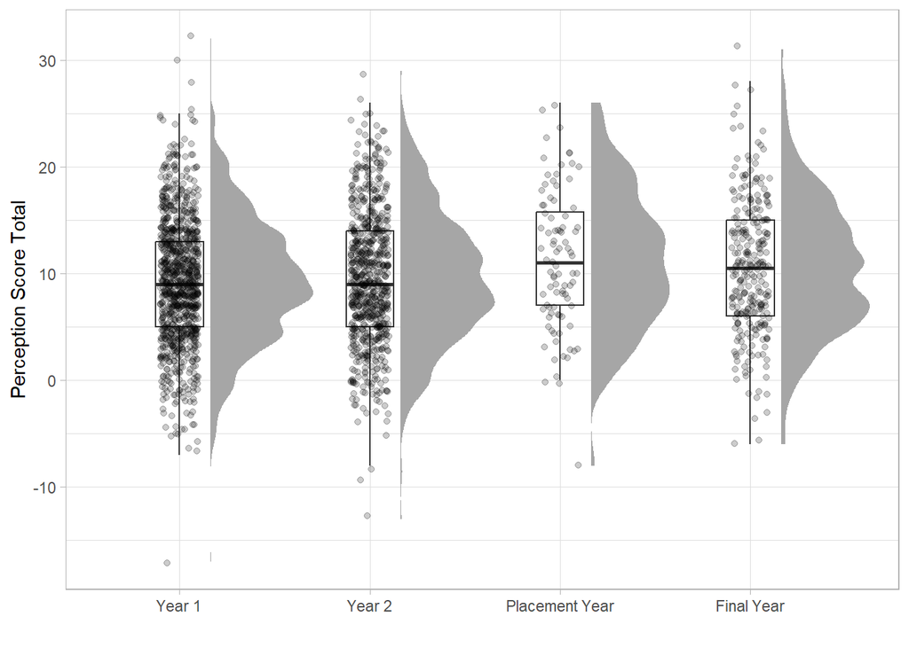

```r
allwaves %>%
  select(Current_Year, Perception_Score_Total) %>%
  ggplot(aes(x = Current_Year, y = Perception_Score_Total)) +
  stat_halfeye(
    adjust = .5,
    width = .6,
    .width = 0,
    justification = -.3,
    point_colour = NA) +
  geom_boxplot(
    width = .25,
    outlier.shape = NA
  ) +
  geom_point(
    size = 1.5,
    alpha = .2,
    position = position_jitter(
      seed = 1, width = .1
    )
  ) +
  theme_light() +
  labs(y = "Perception Score Total",
       x = "")
```

1.1.2 Current_Year + Perception_Score_Mean

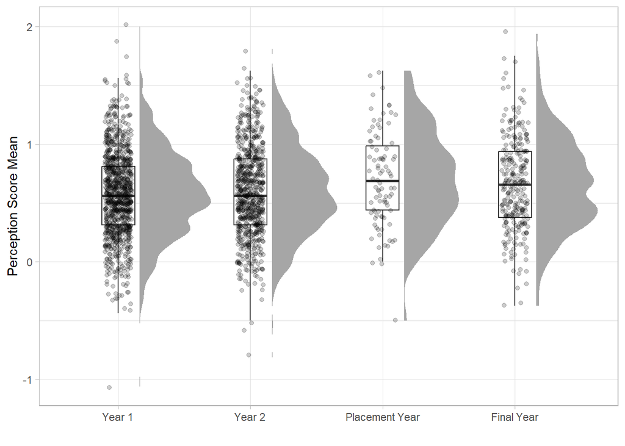

```r
allwaves %>%
  select(Current_Year, Perception_Score_Mean) %>%
  ggplot(aes(x = Current_Year, y = Perception_Score_Mean)) +
  stat_halfeye(
    adjust = .5,
    width = .6,
    .width = 0,
    justification = -.3,
    point_colour = NA) +
  geom_boxplot(
    width = .25,
    outlier.shape = NA
  ) +
  geom_point(
    size = 1.5,
    alpha = .2,
    position = position_jitter(
      seed = 1, width = .1
    )
  ) +
  theme_light() +
  labs(y = "Perception Score Mean",
       x = "")
```

1.1.3 Current_Year + Knowledge_Score_Total

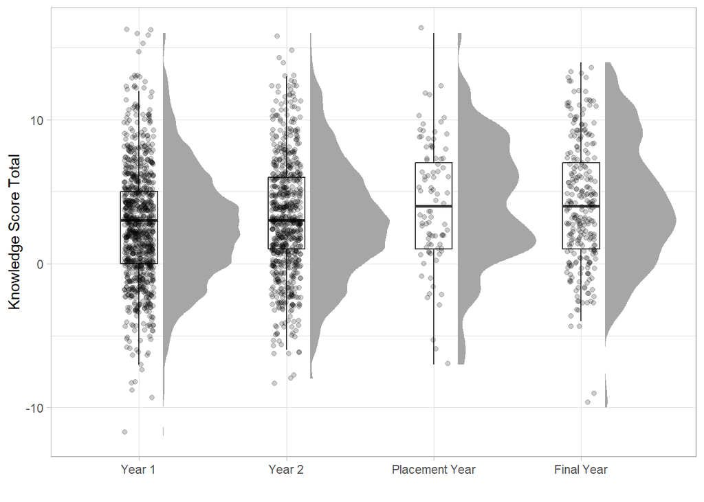

```r
allwaves %>%
  select(Current_Year, Knowledge_Score_Total) %>%
  ggplot(aes(x = Current_Year, y = Knowledge_Score_Total)) +
  stat_halfeye(
    adjust = .5,
    width = .6,
    .width = 0,
    justification = -.3,
    point_colour = NA) +
  geom_boxplot(
    width = .25,
    outlier.shape = NA
  ) +
  geom_point(
    size = 1.5,
    alpha = .2,
    position = position_jitter(
      seed = 1, width = .1
    )
  ) +
  theme_light() +
  labs(y = "Knowledge Score Total",
       x = "")
```

1.1.4 Current_Year + Knowledge_Score_Mean

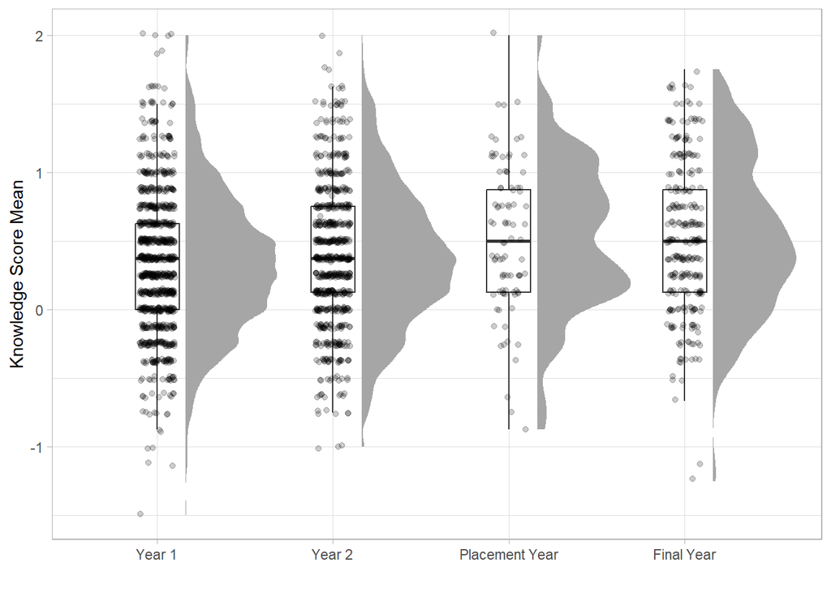

```r
allwaves %>%
  select(Current_Year, Knowledge_Score_Mean) %>%
  ggplot(aes(x = Current_Year, y = Knowledge_Score_Mean)) +
  stat_halfeye(
    adjust = .5,
    width = .6,
    .width = 0,
    justification = -.3,
    point_colour = NA) +
  geom_boxplot(
    width = .25,
    outlier.shape = NA
  ) +
  geom_point(
    size = 1.5,
    alpha = .2,
    position = position_jitter(
      seed = 1, width = .1
    )
  ) +
  theme_light() +
  labs(y = "Knowledge Score Mean",
       x = "")
```

1.1.5 Current_Year + Awareness_Score_Total

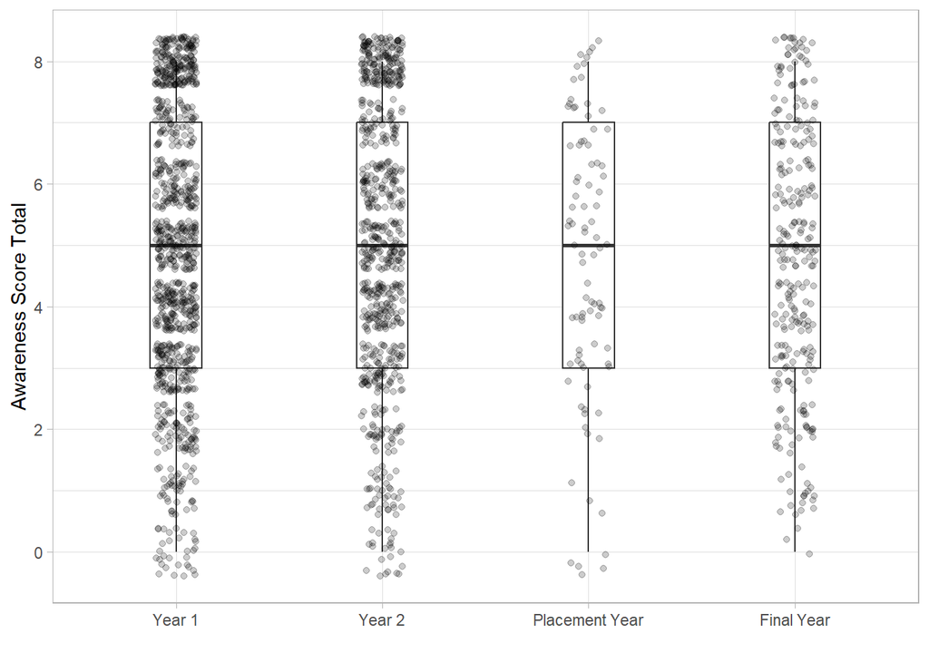

```r
allwaves %>%
  select(Current_Year, Awareness_Score_Total) %>%
  ggplot(aes(x = Current_Year, y = Awareness_Score_Total)) +
  geom_boxplot(
    width = .25,
    outlier.shape = NA
  ) +
  geom_point(
    size = 1.5,
    alpha = .2,
    position = position_jitter(
      seed = 1, width = .1
    )
  ) +
  theme_light() +
  labs(y = "Awareness Score Total",
       x = "")
```

1.1.6 Current_Year + Experience_Score_Total

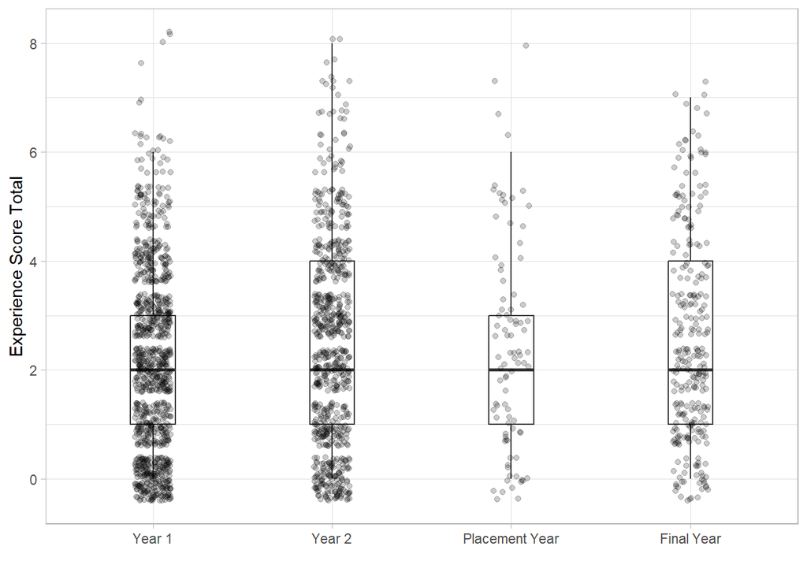

```r
allwaves %>%
  select(Current_Year, Experience_Score_Total) %>%
  ggplot(aes(x = Current_Year, y = Experience_Score_Total)) +
  geom_boxplot(
    width = .25,
    outlier.shape = NA
  ) +
  geom_point(
    size = 1.5,
    alpha = .2,
    position = position_jitter(
      seed = 1, width = .1
    )
  ) +
  theme_light() +
  labs(y = "Experience Score Total",
       x = "")
```

1.2 Current Year Binary Categorical Variables

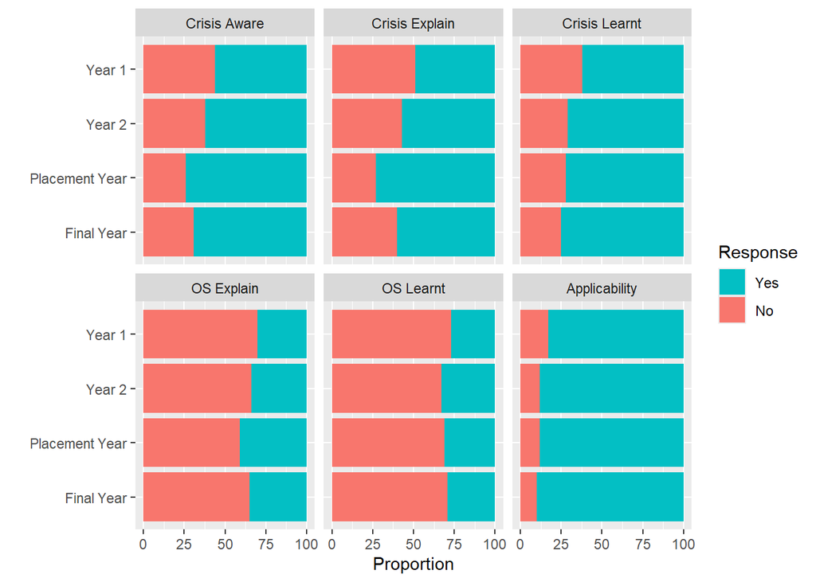

```r
allwaves %>%
  select(Current_Year, crisis_aware, crisis_learnt, crisis_explain, os_explain, os_learnt, applicability) %>%
  pivot_longer(cols = -Current_Year,
               names_to = "Item",
               values_to = "Response") %>%
  group_by(Current_Year) %>%
  count(Item, Response) %>%
  drop_na() %>%
  group_by(Current_Year, Item) %>%
  mutate(Response = as.factor(Response),
         Proportion = round(100*prop.table(n)),
         Item = str_replace(Item, "_", " "),
         Item = str_to_title(Item),
         Item = str_replace(Item, "Os", "OS"),
         Item = fct_expand(Item, "Applicability"),
         Item = fct_relevel(Item, "Applicability", after = Inf),
         Response = case_match(Response, "0" ~ "No", "1" ~ "Yes", .default = Response)) %>%
  ungroup() %>%
  ggplot(aes(y = fct_rev(Current_Year), x = Proportion, fill = fct_rev(Response))) +
  facet_wrap(~Item) +
  geom_col(position = "stack") +
  scale_fill_manual(values = c("#03bfc4", "#F8766D")) +
  guides(fill = guide_legend(title = "Response")) +
  ylab("")
```

2. UKRN Analyses

2.1 Scale Scores

2.1.1 UKRN + Perception_Score_Total

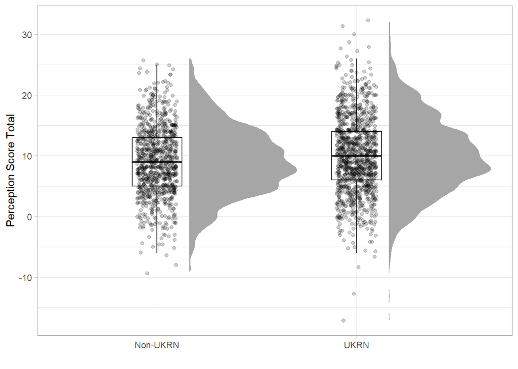

```r
allwaves %>%
  select(UKRN, Perception_Score_Total) %>%
  ggplot(aes(x = UKRN, y = Perception_Score_Total)) +
  stat_halfeye(
    adjust = .5,
    width = .6,
    .width = 0,
    justification = -.3,
    point_colour = NA) +
  geom_boxplot(
    width = .25,
    outlier.shape = NA
  ) +
  geom_point(
    size = 1.5,
    alpha = .2,
    position = position_jitter(
      seed = 1, width = .1
    )
  ) +
  theme_light() +
  labs(y = "Perception Score Total",
       x = "")
```

2.1.2 UKRN + Perception_Score_Mean

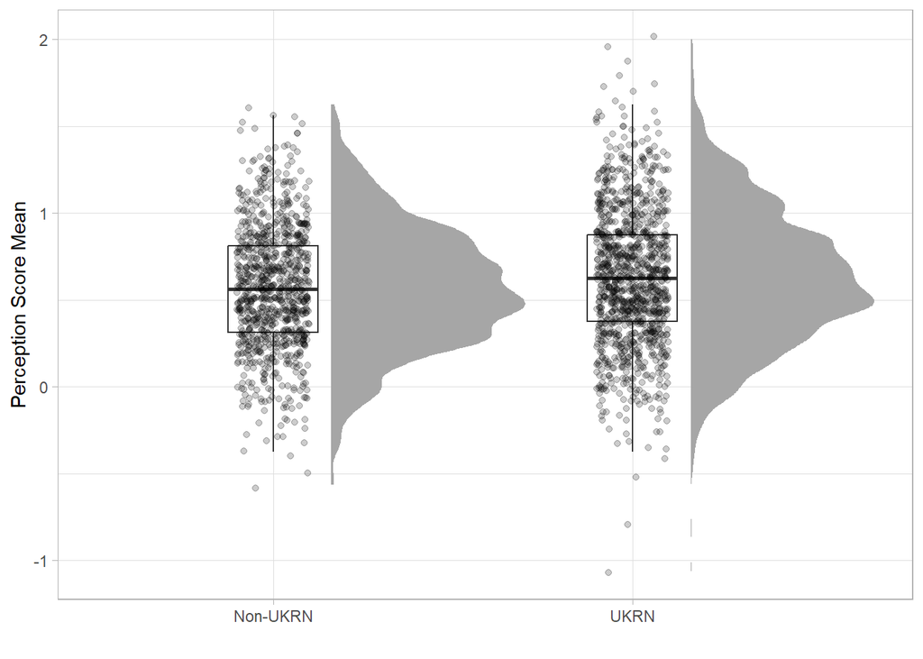

```r
allwaves %>%
  select(UKRN, Perception_Score_Mean) %>%
  ggplot(aes(x = UKRN, y = Perception_Score_Mean)) +
  stat_halfeye(
    adjust = .5,
    width = .6,
    .width = 0,
    justification = -.3,
    point_colour = NA) +
  geom_boxplot(
    width = .25,
    outlier.shape = NA
  ) +
  geom_point(
    size = 1.5,
    alpha = .2,
    position = position_jitter(
      seed = 1, width = .1
    )
  ) +
  theme_light() +
  labs(y = "Perception Score Mean",
       x = "")
```

2.1.3 UKRN + Knowledge_Score_Total

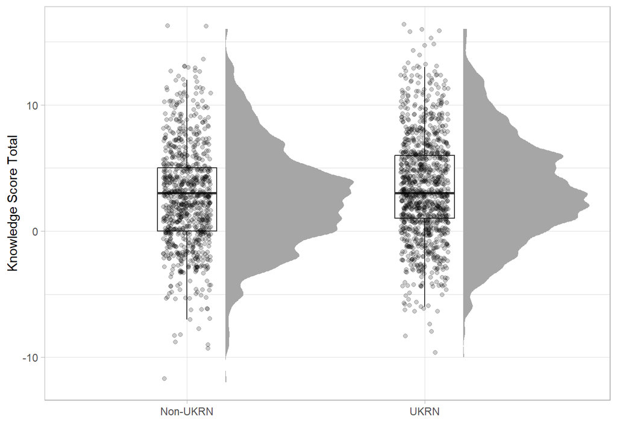

```r
allwaves %>%
  select(UKRN, Knowledge_Score_Total) %>%
  ggplot(aes(x = UKRN, y = Knowledge_Score_Total)) +
  stat_halfeye(
    adjust = .5,
    width = .6,
    .width = 0,
    justification = -.3,
    point_colour = NA) +
  geom_boxplot(
    width = .25,
    outlier.shape = NA
  ) +
  geom_point(
    size = 1.5,
    alpha = .2,
    position = position_jitter(
      seed = 1, width = .1
    )
  ) +
  theme_light() +
  labs(y = "Knowledge Score Total",
       x = "")
```

2.1.4 UKRN + Knowledge_Score_Mean

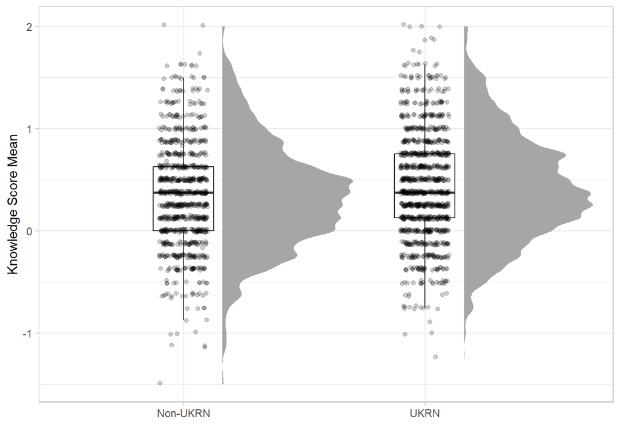

```r
allwaves %>%
  select(UKRN, Knowledge_Score_Mean) %>%
  ggplot(aes(x = UKRN, y = Knowledge_Score_Mean)) +
  stat_halfeye(
    adjust = .5,
    width = .6,
    .width = 0,
    justification = -.3,
    point_colour = NA) +
  geom_boxplot(
    width = .25,
    outlier.shape = NA
  ) +
  geom_point(
    size = 1.5,
    alpha = .2,
    position = position_jitter(
      seed = 1, width = .1
    )
  ) +
  theme_light() +
  labs(y = "Knowledge Score Mean",
       x = "")
```

2.1.5 UKRN + Awareness_Score_Total

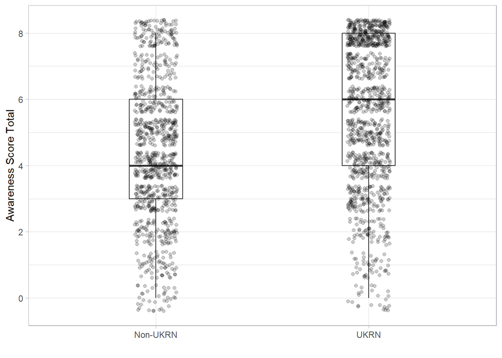

```r
allwaves %>%
  select(UKRN, Awareness_Score_Total) %>%
  ggplot(aes(x = UKRN, y = Awareness_Score_Total)) +
  geom_boxplot(
    width = .25,
    outlier.shape = NA
  ) +
  geom_point(
    size = 1.5,
    alpha = .2,
    position = position_jitter(
      seed = 1, width = .1
    )
  ) +
  theme_light() +
  labs(y = "Awareness Score Total",
       x = "")
```

2.1.6 UKRN + Experience_Score_Total

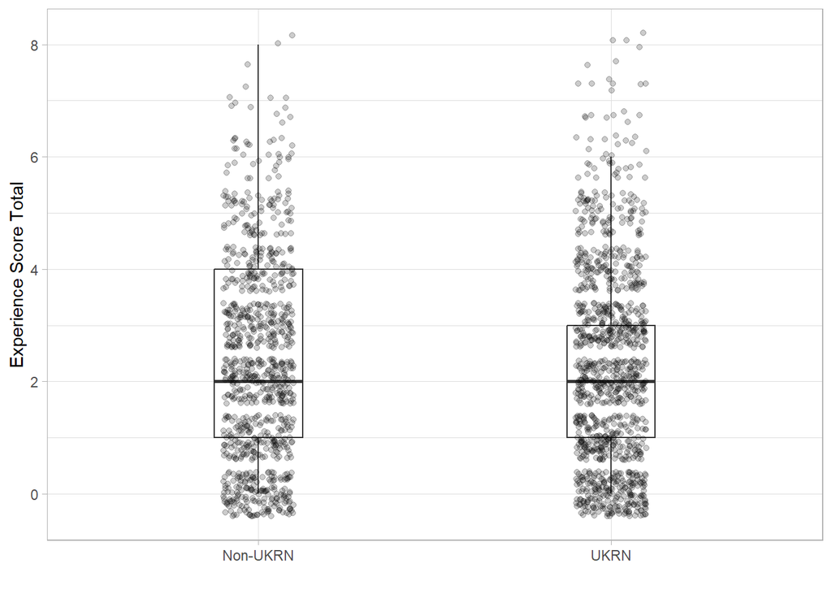

```r
allwaves %>%
  select(UKRN, Experience_Score_Total) %>%
  ggplot(aes(x = UKRN, y = Experience_Score_Total)) +
  geom_boxplot(
    width = .25,
    outlier.shape = NA
  ) +
  geom_point(
    size = 1.5,
    alpha = .2,
    position = position_jitter(
      seed = 1, width = .1
    )
  ) +
  theme_light() +
  labs(y = "Experience Score Total",
       x = "")
```

2.2 UKRN Binary Categorical Variables

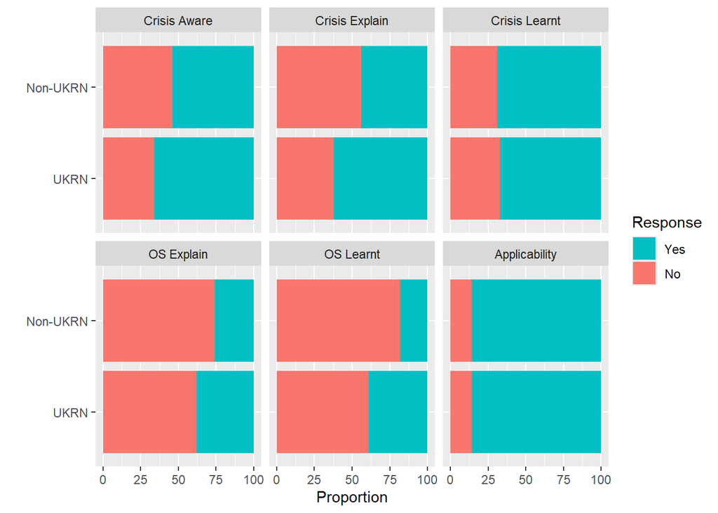

```r
allwaves %>%
  select(UKRN, crisis_aware, crisis_learnt, crisis_explain, os_explain, os_learnt, applicability) %>%
  pivot_longer(cols = -UKRN,
               names_to = "Item",
               values_to = "Response") %>%
  group_by(UKRN) %>%
  count(Item, Response) %>%
  drop_na() %>%
  group_by(UKRN, Item) %>%
  mutate(Response = as.factor(Response),
         Proportion = round(100*prop.table(n)),
         Item = str_replace(Item, "_", " "),
         Item = str_to_title(Item),
         Item = str_replace(Item, "Os", "OS"),
         Item = fct_expand(Item, "Applicability"),
         Item = fct_relevel(Item, "Applicability", after = Inf),
         Response = case_match(Response, "0" ~ "No", "1" ~ "Yes", .default = Response)) %>%
  ungroup() %>%
  ggplot(aes(y = fct_rev(UKRN), x = Proportion, fill = fct_rev(Response))) +
  facet_wrap(~Item) +
  geom_col(position = "stack") +
  scale_fill_manual(values = c("#03bfc4", "#F8766D")) +
  guides(fill = guide_legend(title = "Response")) +
  ylab("")
```

3. Timepoint Analyses

3.1 Scale Scores

3.1.1 Timepoint + Perception_Score_Total

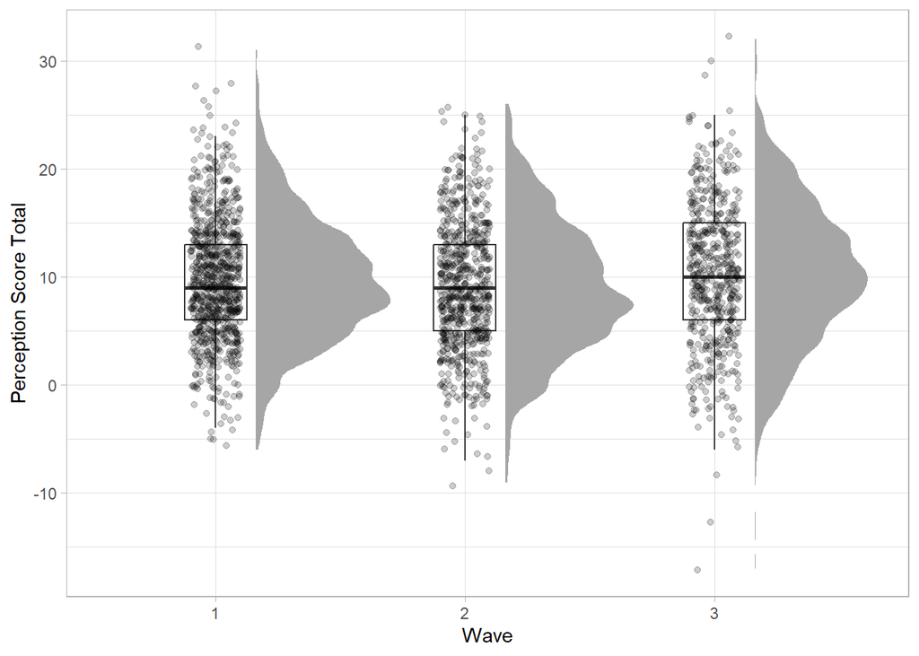

```r
allwaves %>%
  select(timepoint, Perception_Score_Total) %>%
  ggplot(aes(x = timepoint, y = Perception_Score_Total)) +
  stat_halfeye(
    adjust = .5,
    width = .6,
    .width = 0,
    justification = -.3,
    point_colour = NA) +
  geom_boxplot(
    width = .25,
    outlier.shape = NA
  ) +
  geom_point(
    size = 1.5,
    alpha = .2,
    position = position_jitter(
      seed = 1, width = .1
    )
  ) +
  theme_light() +
  labs(y = "Perception Score Total",
       x = "Wave")
```

3.1.2 Timepoint + Perception_Score_Mean

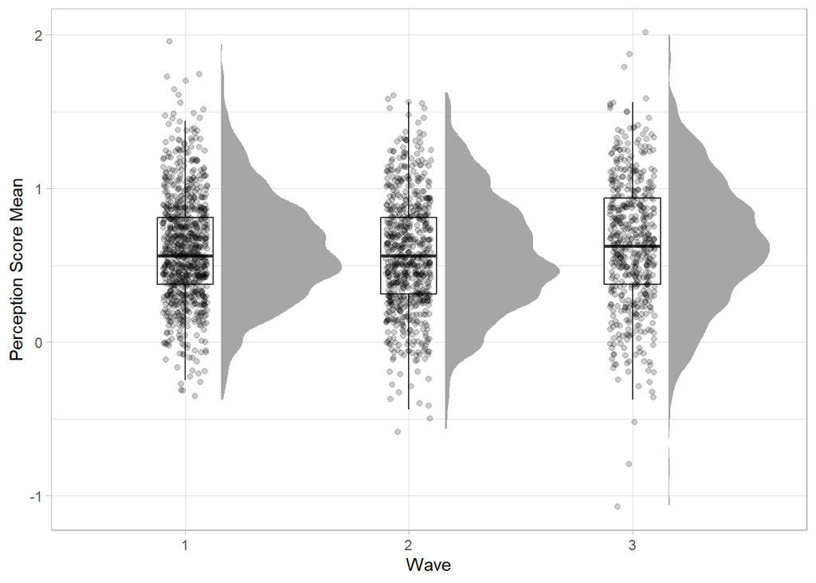

```r
allwaves %>%
  select(timepoint, Perception_Score_Mean) %>%
  ggplot(aes(x = timepoint, y = Perception_Score_Mean)) +
  stat_halfeye(
    adjust = .5,
    width = .6,
    .width = 0,
    justification = -.3,
    point_colour = NA) +
  geom_boxplot(
    width = .25,
    outlier.shape = NA
  ) +
  geom_point(
    size = 1.5,
    alpha = .2,
    position = position_jitter(
      seed = 1, width = .1
    )
  ) +
  theme_light() +
  labs(y = "Perception Score Mean",
       x = "Wave")
```

3.1.3 Timepoint + Knowledge_Score_Total

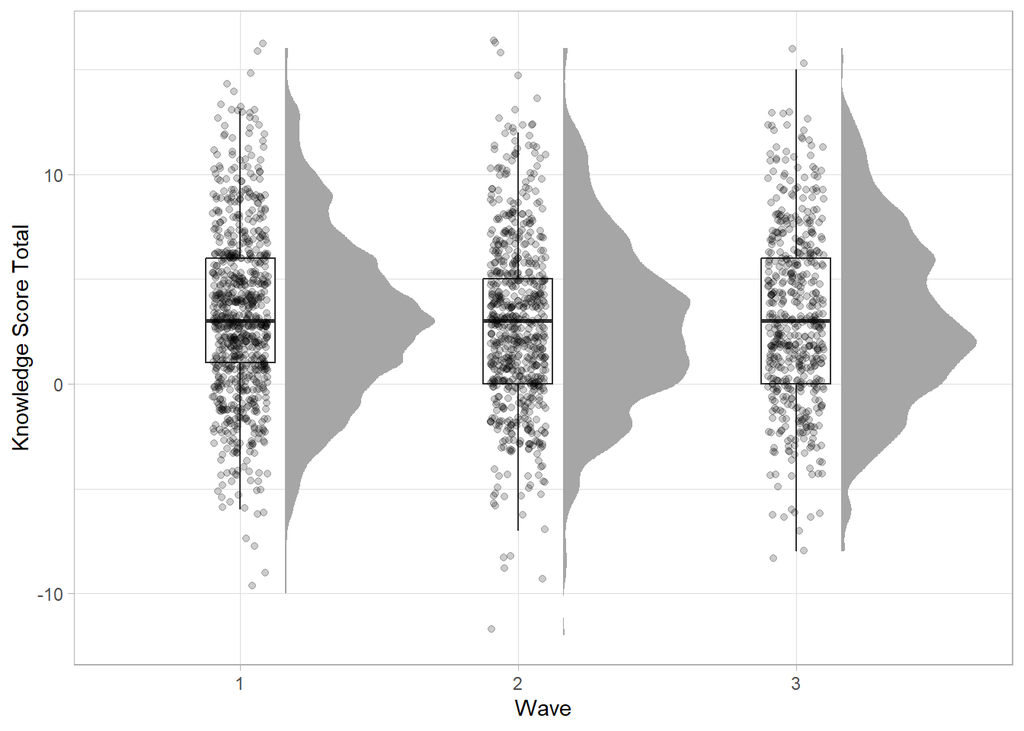

```r
allwaves %>%
  select(timepoint, Knowledge_Score_Total) %>%
  ggplot(aes(x = timepoint, y = Knowledge_Score_Total)) +
  stat_halfeye(
    adjust = .5,
    width = .6,
    .width = 0,
    justification = -.3,
    point_colour = NA) +
  geom_boxplot(
    width = .25,
    outlier.shape = NA
  ) +
  geom_point(
    size = 1.5,
    alpha = .2,
    position = position_jitter(
      seed = 1, width = .1
    )
  ) +
  theme_light() +
  labs(y = "Knowledge Score Total",
       x = "Wave")
```

3.1.4 Timepoint + Knowledge_Score_Mean

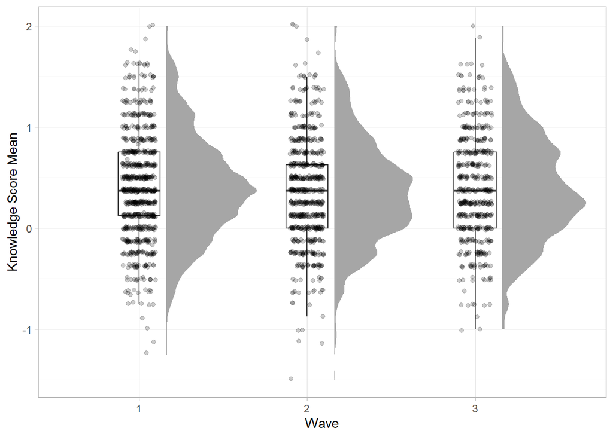

```r
allwaves %>%
  select(timepoint, Knowledge_Score_Mean) %>%
  ggplot(aes(x = timepoint, y = Knowledge_Score_Mean)) +
  stat_halfeye(
    adjust = .5,
    width = .6,
    .width = 0,
    justification = -.3,
    point_colour = NA) +
  geom_boxplot(
    width = .25,
    outlier.shape = NA
  ) +
  geom_point(
    size = 1.5,
    alpha = .2,
    position = position_jitter(
      seed = 1, width = .1
    )
  ) +
  theme_light() +
  labs(y = "Knowledge Score Mean",
       x = "Wave")
```

3.1.5 Timepoint + Awareness_Score_Total

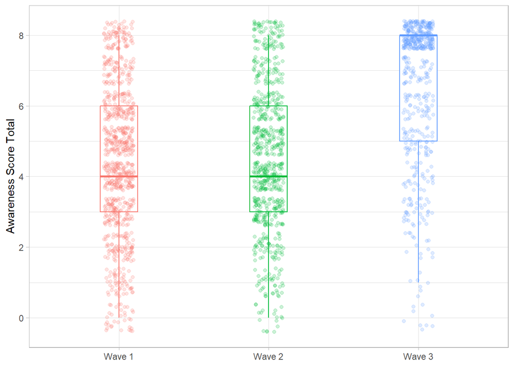

```r
allwaves <- allwaves %>%
  mutate(timepoint = recode(timepoint,
                            '1' = "Wave 1",
                            '2' = "Wave 2",
                            '3' = "Wave 3"))

p1 <- allwaves %>%
  select(timepoint, Awareness_Score_Total) %>%
  ggplot(aes(x = timepoint, y = Awareness_Score_Total, colour = timepoint)) +
  geom_boxplot(
    width = .25,
    outlier.shape = NA
  ) +
  geom_point(
    size = 1.5,
    alpha = .2,
    position = position_jitter(
      seed = 1, width = .1
    )
  ) +
  theme_light() +
  theme(legend.position = "none") +
  labs(y = "Awareness Score Total",
       x = element_blank())

p1
```

3.1.6 Timepoint + Experience_Score_Total

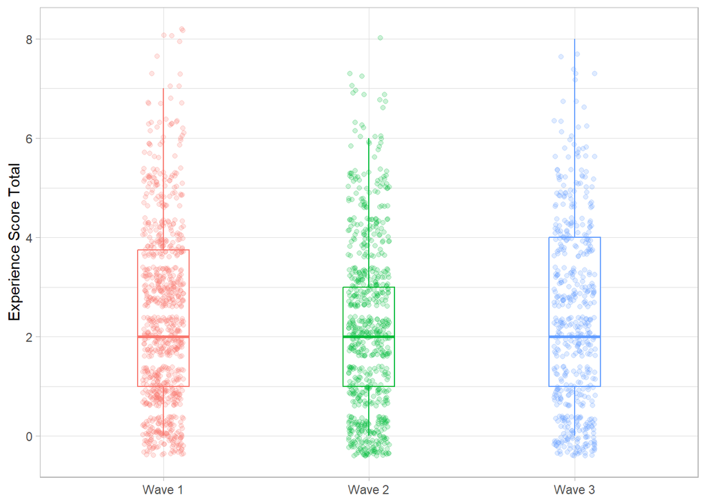

```r
p2 <- allwaves %>%
  select(timepoint, Experience_Score_Total) %>%
  ggplot(aes(x = timepoint, y = Experience_Score_Total, colour = timepoint)) +
  geom_boxplot(
    width = .25,
    outlier.shape = NA
  ) +
  geom_point(
    size = 1.5,
    alpha = .2,
    position = position_jitter(
      seed = 1, width = .1
    )
  ) +
  theme_light() +
  theme(legend.position = "none") +
  labs(y = "Experience Score Total",
       x = element_blank())

p2
```

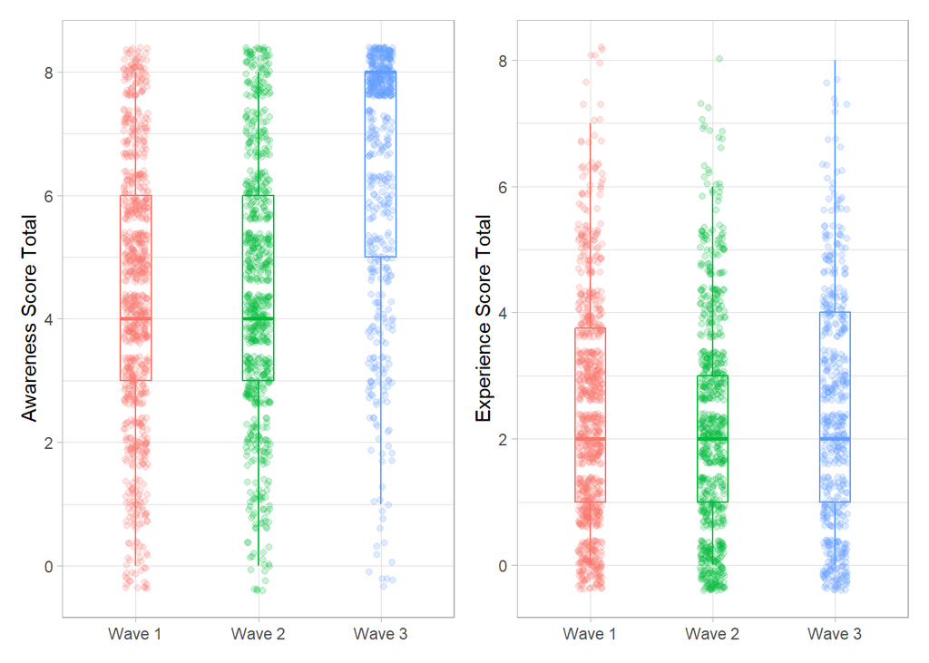

```r
p1 + p2
```

```r
ggsave("Figure 4.png", width = 10,)
```

3.2 Timepoint Binary Categorical Variables

[figure not shown]

```r
allwaves %>%
  select(timepoint, crisis_aware, os_explain, os_learnt, applicability) %>%
  pivot_longer(cols = -timepoint,
               names_to = "Item",
               values_to = "Response") %>%
  group_by(timepoint) %>%
  count(Item, Response) %>%
  drop_na() %>%
  group_by(timepoint, Item) %>%
  mutate(Response = as.factor(Response),
         Proportion = round(100*prop.table(n)),
         Item = str_to_title(Item),
         Item = str_replace(Item, "Os_explain", "Can Explain Open Research"),
         Item = str_replace(Item, "Os_learnt", "Learned About Open Research"),
         Item = str_replace(Item, "Crisis_aware", "Crisis Awareness"),
         Item = str_replace(Item, "Applicability", "Perceived Applicability"),
         Item = fct_expand(Item, "Applicability"),
         Item = fct_relevel(Item, "Applicability", after = Inf),
         Response = case_match(Response, "0" ~ "No", "1" ~ "Yes", .default = Response)) %>%
  ungroup() %>%
  ggplot(aes(y = fct_rev(timepoint), x = Proportion, fill = fct_rev(Response))) +
  facet_wrap(~Item) +
  geom_col(position = "stack") +
  scale_fill_manual(values = c("#03bfc4", "#F8766D")) +
  guides(fill = guide_legend(title = "Response")) +
  ylab("")
```

```r
ggsave("Figure 3.png")
```